# **Universidad de Buenos Aires**

## **Facultad de Ciencias Económicas**

### Cátedra: Bianco

#### **Tipos de muestreo**

```python
pip install ucimlrepo
```

```python
import pandas as pd
from ucimlrepo import fetch_ucirepo
import numpy as np
```

```python
# 1. Traer la base de datos
dataset = fetch_ucirepo(id=697)
df = pd.concat([dataset.data.features, dataset.data.targets], axis=1)

# Más datos del caso:
# https://archive.ics.uci.edu/dataset/697/predict+students+dropout+and+academic+success
```

```python
df
```

|  | Marital Status | Application mode | Application order | Course | Daytime/evening attendance | Previous qualification | Previous qualification (grade) | Nacionality | Mother's qualification | Father's qualification | ... | Curricular units 2nd sem (credited) | Curricular units 2nd sem (enrolled) | Curricular units 2nd sem (evaluations) | Curricular units 2nd sem (approved) | Curricular units 2nd sem (grade) | Curricular units 2nd sem (without evaluations) | Unemployment rate | Inflation rate | GDP | Target |
| --- | --- | --- | --- | --- | --- | --- | --- | --- | --- | --- | --- | --- | --- | --- | --- | --- | --- | --- | --- | --- | --- |
| 0 | 1 | 17 | 5 | 171 | 1 | 1 | 122.0 | 1 | 19 | 12 | ... | 0 | 0 | 0 | 0 | 0.000000 | 0 | 10.8 | 1.4 | 1.74 | Dropout |
| 1 | 1 | 15 | 1 | 9254 | 1 | 1 | 160.0 | 1 | 1 | 3 | ... | 0 | 6 | 6 | 6 | 13.666667 | 0 | 13.9 | -0.3 | 0.79 | Graduate |
| 2 | 1 | 1 | 5 | 9070 | 1 | 1 | 122.0 | 1 | 37 | 37 | ... | 0 | 6 | 0 | 0 | 0.000000 | 0 | 10.8 | 1.4 | 1.74 | Dropout |
| 3 | 1 | 17 | 2 | 9773 | 1 | 1 | 122.0 | 1 | 38 | 37 | ... | 0 | 6 | 10 | 5 | 12.400000 | 0 | 9.4 | -0.8 | -3.12 | Graduate |
| 4 | 2 | 39 | 1 | 8014 | 0 | 1 | 100.0 | 1 | 37 | 38 | ... | 0 | 6 | 6 | 6 | 13.000000 | 0 | 13.9 | -0.3 | 0.79 | Graduate |
| ... | ... | ... | ... | ... | ... | ... | ... | ... | ... | ... | ... | ... | ... | ... | ... | ... | ... | ... | ... | ... | ... |
| 4419 | 1 | 1 | 6 | 9773 | 1 | 1 | 125.0 | 1 | 1 | 1 | ... | 0 | 6 | 8 | 5 | 12.666667 | 0 | 15.5 | 2.8 | -4.06 | Graduate |
| 4420 | 1 | 1 | 2 | 9773 | 1 | 1 | 120.0 | 105 | 1 | 1 | ... | 0 | 6 | 6 | 2 | 11.000000 | 0 | 11.1 | 0.6 | 2.02 | Dropout |
| 4421 | 1 | 1 | 1 | 9500 | 1 | 1 | 154.0 | 1 | 37 | 37 | ... | 0 | 8 | 9 | 1 | 13.500000 | 0 | 13.9 | -0.3 | 0.79 | Dropout |
| 4422 | 1 | 1 | 1 | 9147 | 1 | 1 | 180.0 | 1 | 37 | 37 | ... | 0 | 5 | 6 | 5 | 12.000000 | 0 | 9.4 | -0.8 | -3.12 | Graduate |
| 4423 | 1 | 10 | 1 | 9773 | 1 | 1 | 152.0 | 22 | 38 | 37 | ... | 0 | 6 | 6 | 6 | 13.000000 | 0 | 12.7 | 3.7 | -1.70 | Graduate |

4424 rows × 37 columns

```python
#imprimimos la dimensionalidad del archivo
df.shape
```

```
(4424, 37)
```

**Muestreo Aleatorio Simple**

## Obtener "n" observaciones de modo aleatorio. Puede realizarse con o sin reemplazo

## MAS sin reposición

```python
#generamos una submuestra aleatoria con n=44 sin reposición y luego la imprimimos
muestra_MAS=df.sample(100, random_state=42)
muestra_MAS
```

|  | Marital Status | Application mode | Application order | Course | Daytime/evening attendance | Previous qualification | Previous qualification (grade) | Nacionality | Mother's qualification | Father's qualification | ... | Curricular units 2nd sem (credited) | Curricular units 2nd sem (enrolled) | Curricular units 2nd sem (evaluations) | Curricular units 2nd sem (approved) | Curricular units 2nd sem (grade) | Curricular units 2nd sem (without evaluations) | Unemployment rate | Inflation rate | GDP | Target |
| --- | --- | --- | --- | --- | --- | --- | --- | --- | --- | --- | --- | --- | --- | --- | --- | --- | --- | --- | --- | --- | --- |
| 1255 | 4 | 39 | 1 | 9130 | 1 | 1 | 133.1 | 1 | 3 | 1 | ... | 0 | 6 | 16 | 1 | 10.000000 | 0 | 11.1 | 0.6 | 2.02 | Dropout |
| 3458 | 1 | 17 | 1 | 9238 | 1 | 1 | 125.0 | 1 | 4 | 3 | ... | 0 | 6 | 8 | 6 | 12.142857 | 0 | 16.2 | 0.3 | -0.92 | Graduate |
| 3390 | 1 | 17 | 1 | 9853 | 1 | 1 | 133.0 | 1 | 38 | 38 | ... | 0 | 7 | 7 | 7 | 12.285714 | 0 | 16.2 | 0.3 | -0.92 | Graduate |
| 1497 | 1 | 17 | 2 | 9670 | 1 | 1 | 110.0 | 1 | 1 | 1 | ... | 0 | 6 | 8 | 5 | 13.000000 | 0 | 15.5 | 2.8 | -4.06 | Graduate |
| 1536 | 1 | 39 | 1 | 9500 | 1 | 1 | 130.0 | 1 | 37 | 19 | ... | 0 | 7 | 14 | 0 | 0.000000 | 0 | 11.1 | 0.6 | 2.02 | Dropout |
| ... | ... | ... | ... | ... | ... | ... | ... | ... | ... | ... | ... | ... | ... | ... | ... | ... | ... | ... | ... | ... | ... |
| 1188 | 1 | 17 | 1 | 9254 | 1 | 1 | 128.0 | 1 | 19 | 1 | ... | 0 | 6 | 10 | 4 | 11.500000 | 0 | 13.9 | -0.3 | 0.79 | Graduate |
| 1717 | 2 | 39 | 1 | 9500 | 1 | 1 | 100.0 | 1 | 37 | 38 | ... | 0 | 8 | 16 | 1 | 10.000000 | 1 | 12.7 | 3.7 | -1.70 | Enrolled |
| 457 | 1 | 43 | 1 | 9853 | 1 | 1 | 140.0 | 1 | 37 | 19 | ... | 0 | 6 | 8 | 5 | 12.000000 | 0 | 12.7 | 3.7 | -1.70 | Dropout |
| 4035 | 2 | 7 | 1 | 9130 | 1 | 2 | 110.0 | 1 | 19 | 19 | ... | 0 | 6 | 6 | 0 | 0.000000 | 0 | 16.2 | 0.3 | -0.92 | Dropout |
| 3198 | 1 | 7 | 1 | 9254 | 1 | 3 | 110.0 | 1 | 19 | 19 | ... | 0 | 6 | 6 | 0 | 0.000000 | 0 | 16.2 | 0.3 | -0.92 | Dropout |

100 rows × 37 columns

```python
muestra_MAS.shape
```

```
(100, 37)
```

## MAS con reposición

```python
#generamos una submuestra aleatoria con n=44 con reposición y luego la imprimimos
muestra_MAS_crepo=df.sample(100, random_state=123, replace= True)
muestra_MAS_crepo
```

|  | Marital Status | Application mode | Application order | Course | Daytime/evening attendance | Previous qualification | Previous qualification (grade) | Nacionality | Mother's qualification | Father's qualification | ... | Curricular units 2nd sem (credited) | Curricular units 2nd sem (enrolled) | Curricular units 2nd sem (evaluations) | Curricular units 2nd sem (approved) | Curricular units 2nd sem (grade) | Curricular units 2nd sem (without evaluations) | Unemployment rate | Inflation rate | GDP | Target |
| --- | --- | --- | --- | --- | --- | --- | --- | --- | --- | --- | --- | --- | --- | --- | --- | --- | --- | --- | --- | --- | --- |
| 3582 | 1 | 39 | 1 | 9991 | 0 | 1 | 133.1 | 1 | 38 | 37 | ... | 0 | 5 | 0 | 0 | 0.000000 | 0 | 10.8 | 1.4 | 1.74 | Dropout |
| 3454 | 1 | 17 | 1 | 9147 | 1 | 1 | 117.0 | 1 | 37 | 37 | ... | 0 | 5 | 11 | 1 | 10.000000 | 0 | 9.4 | -0.8 | -3.12 | Dropout |
| 1346 | 1 | 17 | 4 | 9773 | 1 | 1 | 134.0 | 1 | 1 | 1 | ... | 0 | 6 | 6 | 6 | 13.500000 | 0 | 16.2 | 0.3 | -0.92 | Graduate |
| 4060 | 1 | 5 | 1 | 9130 | 1 | 1 | 157.0 | 1 | 5 | 43 | ... | 0 | 6 | 6 | 6 | 14.833333 | 0 | 8.9 | 1.4 | 3.51 | Graduate |
| 1593 | 1 | 1 | 3 | 171 | 1 | 1 | 129.0 | 1 | 38 | 37 | ... | 0 | 0 | 0 | 0 | 0.000000 | 0 | 9.4 | -0.8 | -3.12 | Dropout |
| ... | ... | ... | ... | ... | ... | ... | ... | ... | ... | ... | ... | ... | ... | ... | ... | ... | ... | ... | ... | ... | ... |
| 3373 | 1 | 17 | 1 | 9147 | 1 | 1 | 130.0 | 1 | 37 | 37 | ... | 0 | 5 | 6 | 5 | 11.833333 | 0 | 13.9 | -0.3 | 0.79 | Graduate |
| 3505 | 1 | 17 | 3 | 9147 | 1 | 1 | 127.0 | 1 | 37 | 37 | ... | 0 | 5 | 13 | 0 | 0.000000 | 0 | 9.4 | -0.8 | -3.12 | Dropout |
| 1443 | 1 | 17 | 1 | 9003 | 1 | 1 | 170.0 | 1 | 1 | 4 | ... | 0 | 6 | 10 | 0 | 0.000000 | 0 | 16.2 | 0.3 | -0.92 | Dropout |
| 3997 | 4 | 39 | 2 | 9556 | 1 | 19 | 133.1 | 1 | 19 | 19 | ... | 0 | 8 | 11 | 8 | 12.300000 | 0 | 10.8 | 1.4 | 1.74 | Graduate |
| 979 | 1 | 18 | 1 | 9003 | 1 | 1 | 133.1 | 1 | 1 | 38 | ... | 3 | 9 | 14 | 8 | 12.250000 | 0 | 15.5 | 2.8 | -4.06 | Graduate |

100 rows × 37 columns

Se observan repetidos los índices 1346 y 3252.

```python
muestra_MAS_crepo.shape
```

```
(100, 37)
```

## Muestreo por Porcentaje

```python
#generamos una submuestra aleatoria por porcentaje sin reposición y luego la imprimimos
muestra_MASporc=df.sample(frac=0.023, random_state=42) # con el parámetro frac=, se puede extraer una muestra pero por porcentaje del total.
muestra_MASporc.shape
```

```
(102, 37)
```

```python
#generamos una submuestra aleatoria por porcentaje con reposición y luego la imprimimos
muestra_MASporcSR=df.sample(frac=0.023, random_state=42,replace=False) # con el parámetro frac=, se puede extraer una muestra pero por porcentaje del total.
muestra_MASporcSR.shape
```

```
(102, 37)
```

## Muestreo con filtro sobre variable

```python
muestra_FILT=df[(df['Marital Status']==4)].sample(15)#generamos un submuestra de 10 elementos con la condición que "Marital Status" sea igual a 4.
muestra_FILT
```

|  | Marital Status | Application mode | Application order | Course | Daytime/evening attendance | Previous qualification | Previous qualification (grade) | Nacionality | Mother's qualification | Father's qualification | ... | Curricular units 2nd sem (credited) | Curricular units 2nd sem (enrolled) | Curricular units 2nd sem (evaluations) | Curricular units 2nd sem (approved) | Curricular units 2nd sem (grade) | Curricular units 2nd sem (without evaluations) | Unemployment rate | Inflation rate | GDP | Target |
| --- | --- | --- | --- | --- | --- | --- | --- | --- | --- | --- | --- | --- | --- | --- | --- | --- | --- | --- | --- | --- | --- |
| 4017 | 4 | 39 | 1 | 8014 | 0 | 1 | 133.1 | 1 | 37 | 37 | ... | 0 | 5 | 5 | 0 | 0.000000 | 0 | 8.9 | 1.4 | 3.51 | Dropout |
| 3893 | 4 | 39 | 1 | 9085 | 1 | 1 | 110.0 | 1 | 37 | 37 | ... | 0 | 5 | 11 | 2 | 10.500000 | 1 | 9.4 | -0.8 | -3.12 | Dropout |
| 1212 | 4 | 39 | 1 | 9500 | 1 | 19 | 133.1 | 1 | 38 | 1 | ... | 0 | 8 | 9 | 8 | 13.630000 | 1 | 9.4 | -0.8 | -3.12 | Graduate |
| 3637 | 4 | 39 | 1 | 9853 | 1 | 19 | 133.1 | 1 | 38 | 19 | ... | 0 | 7 | 8 | 6 | 12.666667 | 0 | 8.9 | 1.4 | 3.51 | Enrolled |
| 920 | 4 | 39 | 1 | 8014 | 0 | 19 | 140.0 | 1 | 37 | 37 | ... | 0 | 6 | 9 | 5 | 10.400000 | 0 | 10.8 | 1.4 | 1.74 | Graduate |
| 3802 | 4 | 43 | 1 | 8014 | 0 | 1 | 140.0 | 1 | 38 | 37 | ... | 2 | 7 | 10 | 7 | 11.714286 | 0 | 12.7 | 3.7 | -1.70 | Graduate |
| 2906 | 4 | 39 | 2 | 8014 | 0 | 1 | 160.0 | 1 | 37 | 38 | ... | 0 | 6 | 9 | 6 | 11.333333 | 0 | 10.8 | 1.4 | 1.74 | Graduate |
| 3459 | 4 | 43 | 4 | 9991 | 0 | 12 | 133.1 | 1 | 37 | 37 | ... | 0 | 5 | 5 | 0 | 0.000000 | 0 | 7.6 | 2.6 | 0.32 | Dropout |
| 409 | 4 | 39 | 1 | 9085 | 1 | 1 | 133.1 | 1 | 34 | 34 | ... | 0 | 5 | 5 | 0 | 0.000000 | 0 | 7.6 | 2.6 | 0.32 | Dropout |
| 2031 | 4 | 39 | 1 | 9254 | 1 | 1 | 140.0 | 1 | 38 | 37 | ... | 2 | 8 | 8 | 0 | 0.000000 | 2 | 12.7 | 3.7 | -1.70 | Dropout |
| 2940 | 4 | 39 | 1 | 8014 | 0 | 3 | 100.0 | 1 | 37 | 37 | ... | 0 | 6 | 6 | 6 | 12.333333 | 0 | 9.4 | -0.8 | -3.12 | Graduate |
| 4250 | 4 | 39 | 1 | 9500 | 1 | 19 | 133.1 | 1 | 37 | 37 | ... | 0 | 8 | 11 | 5 | 11.832000 | 4 | 9.4 | -0.8 | -3.12 | Dropout |
| 3979 | 4 | 39 | 1 | 9773 | 1 | 38 | 133.1 | 1 | 19 | 19 | ... | 0 | 6 | 7 | 5 | 12.600000 | 0 | 16.2 | 0.3 | -0.92 | Enrolled |
| 4162 | 4 | 43 | 1 | 9853 | 1 | 1 | 133.1 | 100 | 19 | 22 | ... | 0 | 6 | 9 | 3 | 11.000000 | 0 | 7.6 | 2.6 | 0.32 | Dropout |
| 4112 | 4 | 39 | 1 | 9500 | 1 | 1 | 140.0 | 1 | 38 | 37 | ... | 0 | 8 | 11 | 7 | 12.160000 | 0 | 10.8 | 1.4 | 1.74 | Graduate |

15 rows × 37 columns

También se podría hacer con un valor mayor o menor a de una variable. Por ejemplo la edad, si tuvieramos el caso.

## Reducir el muestreo de la clase mayoritaria

Generar la condición para que tome la misma cantidad de muestra que su opuesto minoritario. Esto se suele usar para muestras desbalanceadas, muy importantes en los proyectos de clasificación.

```python
df.groupby('Daytime/evening attendance').count()['Previous qualification']
```

| Daytime/evening attendance | Previous qualification |
| --- | --- |
| 0 | 483 |
| 1 | 3941 |

**dtype:** int64

```python
#se toman muestras de los casos según el valor que toma cada clase
#se concatenan las muestras
df_true=df[df['Daytime/evening attendance']==1]
df_false=df[df['Daytime/evening attendance']==0]
muestra_balance=pd.concat([df_false, df_true.sample(df_false.shape[0])]) # se genera la condición para que tome la misma cantidad de muestra que su opuesto minoritario.
muestra_balance.shape #imprimimos la dimensión de la submuestra generada
```

```
(966, 37)
```

```python
muestra_balance.groupby('Daytime/evening attendance').count()['Previous qualification']
```

| Daytime/evening attendance | Previous qualification |
| --- | --- |
| 0 | 483 |
| 1 | 483 |

**dtype:** int64

## Muestreo Sistemático

Si quisieramos hacer un muestreo rápido, puede incurrirse en un muestreo sistemático que toma una instancia cada $k$ observación.

```python
n = 100  # cantidad de observaciones que queremos en la muestra
N = len(df) # tamaño de la población

k = N // n  # división entera

inicio = np.random.randint(0, k)
indices = np.arange(inicio, N, k) # Tomamos cada k-ésima observación
# indices = indices[:n]   # Ajuste por si nos pasamos de n para que solo tome esa cantidad de n, si querémos limitarlo.

muestra_sistem = df.iloc[indices]

muestra_sistem
```

|  | Marital Status | Application mode | Application order | Course | Daytime/evening attendance | Previous qualification | Previous qualification (grade) | Nacionality | Mother's qualification | Father's qualification | ... | Curricular units 2nd sem (credited) | Curricular units 2nd sem (enrolled) | Curricular units 2nd sem (evaluations) | Curricular units 2nd sem (approved) | Curricular units 2nd sem (grade) | Curricular units 2nd sem (without evaluations) | Unemployment rate | Inflation rate | GDP | Target |
| --- | --- | --- | --- | --- | --- | --- | --- | --- | --- | --- | --- | --- | --- | --- | --- | --- | --- | --- | --- | --- | --- |
| 5 | 2 | 39 | 1 | 9991 | 0 | 19 | 133.1 | 1 | 37 | 37 | ... | 0 | 5 | 17 | 5 | 11.500000 | 5 | 16.2 | 0.3 | -0.92 | Graduate |
| 49 | 1 | 1 | 1 | 9238 | 1 | 1 | 139.0 | 1 | 37 | 38 | ... | 0 | 6 | 7 | 6 | 12.833333 | 0 | 12.7 | 3.7 | -1.70 | Graduate |
| 93 | 2 | 39 | 1 | 9853 | 1 | 10 | 133.1 | 1 | 37 | 34 | ... | 0 | 6 | 14 | 0 | 0.000000 | 1 | 7.6 | 2.6 | 0.32 | Dropout |
| 137 | 1 | 1 | 1 | 9773 | 1 | 1 | 153.0 | 1 | 1 | 1 | ... | 0 | 6 | 6 | 6 | 14.833333 | 0 | 8.9 | 1.4 | 3.51 | Graduate |
| 181 | 1 | 44 | 1 | 9991 | 0 | 39 | 140.0 | 1 | 37 | 19 | ... | 2 | 6 | 7 | 6 | 13.166667 | 1 | 9.4 | -0.8 | -3.12 | Enrolled |
| ... | ... | ... | ... | ... | ... | ... | ... | ... | ... | ... | ... | ... | ... | ... | ... | ... | ... | ... | ... | ... | ... |
| 4229 | 2 | 39 | 1 | 9085 | 1 | 1 | 133.1 | 1 | 36 | 36 | ... | 0 | 5 | 5 | 0 | 0.000000 | 5 | 9.4 | -0.8 | -3.12 | Dropout |
| 4273 | 1 | 17 | 2 | 9085 | 1 | 1 | 123.0 | 1 | 3 | 19 | ... | 0 | 5 | 7 | 3 | 12.666667 | 0 | 7.6 | 2.6 | 0.32 | Enrolled |
| 4317 | 1 | 17 | 1 | 9670 | 1 | 1 | 118.0 | 1 | 1 | 19 | ... | 0 | 6 | 6 | 6 | 14.000000 | 0 | 12.4 | 0.5 | 1.79 | Graduate |
| 4361 | 1 | 17 | 1 | 9500 | 1 | 1 | 145.0 | 1 | 3 | 3 | ... | 0 | 8 | 8 | 8 | 13.347500 | 0 | 9.4 | -0.8 | -3.12 | Graduate |
| 4405 | 1 | 1 | 4 | 9500 | 1 | 1 | 160.0 | 1 | 37 | 37 | ... | 0 | 8 | 8 | 7 | 14.314286 | 0 | 12.7 | 3.7 | -1.70 | Graduate |

101 rows × 37 columns

## Muestreo por Conglomerados

A los fines de la ejemmplificación, asumamos que la categoría curso representa también sucursales distantes físicamente.

```python
clusters = df['Course'].unique()

num_clusters = 4  # cantidad de carreras a seleccionar
selected_clusters = np.random.choice(clusters, size=num_clusters, replace=False) # en este caso se hace una selección de carrera aleatoria.

df_clusters = df[df['Course'].isin(selected_clusters)]
n_por_cluster = 25

muestra_congl = (
    df_clusters
    .groupby('Course', group_keys=False)
    .apply(lambda x: x.sample(n=min(len(x), n_por_cluster)))
)

print("Clusters seleccionados:", selected_clusters)
print("Tamaño muestra:", len(muestra_congl))

muestra_congl.head()
```

```
Clusters seleccionados: [9853 9773 9500 9119]
Tamaño muestra: 100
```

|  | Marital Status | Application mode | Application order | Course | Daytime/evening attendance | Previous qualification | Previous qualification (grade) | Nacionality | Mother's qualification | Father's qualification | ... | Curricular units 2nd sem (credited) | Curricular units 2nd sem (enrolled) | Curricular units 2nd sem (evaluations) | Curricular units 2nd sem (approved) | Curricular units 2nd sem (grade) | Curricular units 2nd sem (without evaluations) | Unemployment rate | Inflation rate | GDP | Target |
| --- | --- | --- | --- | --- | --- | --- | --- | --- | --- | --- | --- | --- | --- | --- | --- | --- | --- | --- | --- | --- | --- |
| 2338 | 1 | 17 | 5 | 9119 | 1 | 1 | 126.0 | 1 | 38 | 38 | ... | 0 | 6 | 8 | 3 | 13.333333 | 0 | 11.1 | 0.6 | 2.02 | Dropout |
| 95 | 1 | 15 | 1 | 9119 | 1 | 1 | 130.0 | 26 | 38 | 3 | ... | 0 | 5 | 11 | 3 | 13.250000 | 0 | 13.9 | -0.3 | 0.79 | Enrolled |
| 2205 | 1 | 44 | 1 | 9119 | 1 | 39 | 180.0 | 1 | 1 | 1 | ... | 1 | 6 | 10 | 6 | 14.125000 | 0 | 12.4 | 0.5 | 1.79 | Enrolled |
| 3563 | 1 | 44 | 1 | 9119 | 1 | 39 | 160.0 | 1 | 3 | 38 | ... | 2 | 7 | 7 | 2 | 16.000000 | 0 | 8.9 | 1.4 | 3.51 | Dropout |
| 3608 | 1 | 17 | 1 | 9119 | 1 | 1 | 125.0 | 1 | 19 | 1 | ... | 0 | 5 | 7 | 5 | 14.571429 | 0 | 11.1 | 0.6 | 2.02 | Dropout |

5 rows × 37 columns

```python
muestra_congl.groupby('Course').count()['Previous qualification']
```

| Course | Previous qualification |
| --- | --- |
| 9119 | 25 |
| 9500 | 25 |
| 9773 | 25 |
| 9853 | 25 |

**dtype:** int64

El uso de conglomerados acá es didáctico, no necesario. Elegimos muestreos por conglomerados cuando trabajar a nivel individual es costoso o difícil. En este caso, las carreras funcionan como unidades naturales de agrupación. Esto simplifica el diseño y reduce costos, pero introduce mayor variabilidad respecto a un muestreo aleatorio.

## Muestreo Estratificado

Hagamos un estratificado por género

```python
n = 100  # tamaño deseado

# Calculamos proporción de cada género
proporciones = df['Gender'].value_counts(normalize=True) ## Normalize = True: nos ahorra un paso, devuelve proporciones. Sino devolvería frecuencias absolutas y deberíamos dividirla por el total.
n_por_estrato = (proporciones * n).round().astype(int)

diferencia = n - n_por_estrato.sum() # Ajuste por si hay diferencias por redondeo
if diferencia != 0:
    # Ajustamos al estrato más grande
    estrato_mayor = n_por_estrato.idxmax()
    n_por_estrato[estrato_mayor] += diferencia
```

```python
#  muestreo dentro de cada estrato

muestra = []
for genero, tamaño in n_por_estrato.items():
    df_estrato = df[df['Gender'] == genero]
    muestra_estrato = df_estrato.sample(n=tamaño, replace=False)
    muestra.append(muestra_estrato)
muestra_estrato = pd.concat(muestra)
```

```python
# Crear un DataFrame con ambas distribuciones
comparacion = pd.DataFrame({
    'Poblacion': df['Gender'].value_counts(normalize=True),
    'Muestra por estrato': muestra_estrato['Gender'].value_counts(normalize=True)
})

comparacion
```

| Gender | Poblacion | Muestra por estrato |
| --- | --- | --- |
| 0 | 0.648282 | 0.65 |
| 1 | 0.351718 | 0.35 |

## Comparación

```python
# Lista de datasets
datasets = {
    "Población": df,
    "MAS": muestra_MAS,
    "MAS_crepo": muestra_MAS_crepo,
    "MAS_porcentaje": muestra_MASporc,
    "MAS_porcentaje_SR": muestra_MASporcSR,
    "Balanceada": muestra_balance,
    "Sistemático": muestra_sistem,
    "Conglomerados": muestra_congl,
    "Estratificado": muestra_estrato
}

# Función para calcular proporciones
def distribucion_target(data):
    return data['Target'].value_counts(normalize=True)

# Construcción de tabla
tabla = pd.DataFrame()

for nombre, data in datasets.items():
    dist = distribucion_target(data)
    tabla[nombre] = dist

tabla = tabla.fillna(0) # Ordenar columnas y completar faltantes
tabla_final = tabla.T # Transponer para mejor lectura
tabla_final = tabla_final.round(4) # Redondeo

tabla_final
```

| Target | Graduate | Dropout | Enrolled |
| --- | --- | --- | --- |
| Población | 0.4993 | 0.3212 | 0.1795 |
| MAS | 0.4900 | 0.3300 | 0.1800 |
| MAS_crepo | 0.4600 | 0.3600 | 0.1800 |
| MAS_porcentaje | 0.5000 | 0.3235 | 0.1765 |
| MAS_porcentaje_SR | 0.5000 | 0.3235 | 0.1765 |
| Balanceada | 0.4617 | 0.3778 | 0.1605 |
| Sistemático | 0.4950 | 0.3069 | 0.1980 |
| Conglomerados | 0.3900 | 0.3800 | 0.2300 |
| Estratificado | 0.4500 | 0.3300 | 0.2200 |

```python
# Lista de datasets
datasets = {
    "Población": df,
    "MAS": muestra_MAS,
    "MAS_crepo": muestra_MAS_crepo,
    "MAS_porcentaje": muestra_MASporc,
    "MAS_porcentaje_SR": muestra_MASporcSR,
    "Balanceada": muestra_balance,
    "Sistemático": muestra_sistem,
    "Conglomerados": muestra_congl,
    "Estratificado": muestra_estrato
}

variable = "Curricular units 1st sem (grade)" # Variable a analizar

# Construcción de tabla

resultados = []
for nombre, data in datasets.items():
    serie = data[variable].dropna()
    resultados.append({
        "Método": nombre,
        "Media": serie.mean(),
        "Desvío": serie.std(),
        "Mínimo": serie.min(),
        "Máximo": serie.max()
    })
tabla = pd.DataFrame(resultados)
tabla = tabla.round(2)

tabla
```

|  | Método | Media | Desvío | Mínimo | Máximo |
| --- | --- | --- | --- | --- | --- |
| 0 | Población | 10.64 | 4.84 | 0.0 | 18.88 |
| 1 | MAS | 10.37 | 5.21 | 0.0 | 17.00 |
| 2 | MAS_crepo | 9.71 | 5.13 | 0.0 | 16.00 |
| 3 | MAS_porcentaje | 10.42 | 5.17 | 0.0 | 17.00 |
| 4 | MAS_porcentaje_SR | 10.42 | 5.17 | 0.0 | 17.00 |
| 5 | Balanceada | 10.15 | 4.98 | 0.0 | 18.00 |
| 6 | Sistemático | 10.22 | 5.40 | 0.0 | 16.40 |
| 7 | Conglomerados | 11.24 | 4.58 | 0.0 | 17.00 |
| 8 | Estratificado | 9.79 | 5.51 | 0.0 | 16.00 |

Esto siempre depende del problema y de lo que queremos estudiar y que criterio implementamos para poder parecernos a la población. Tenemos que tener en cuenta que dificilmente tengamos los datos de la población para poder comparar con el muestreo a seleccionar.

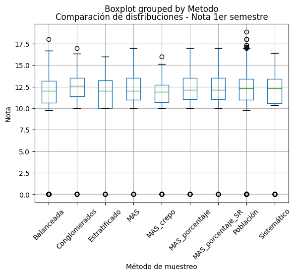

```python
import pandas as pd
import matplotlib.pyplot as plt

# -------------------------------
# Variable a analizar
# -------------------------------
variable = "Curricular units 1st sem (grade)"

# -------------------------------
# Unificar datasets
# -------------------------------
dataframes = []

datasets = {
    "Población": df,
    "MAS": muestra_MAS,
    "MAS_crepo": muestra_MAS_crepo,
    "MAS_porcentaje": muestra_MASporc,
    "MAS_porcentaje_SR": muestra_MASporcSR,
    "Balanceada": muestra_balance,
    "Sistemático": muestra_sistem,
    "Conglomerados": muestra_congl,
    "Estratificado": muestra_estrato
}

for nombre, data in datasets.items():
   temp = data[[variable]].copy()
   temp["Metodo"] = nombre
   dataframes.append(temp)

df_plot = pd.concat(dataframes)

# Eliminamos NA
df_plot = df_plot.dropna()


# Gráfico
plt.figure(figsize=(12,6))

df_plot.boxplot(column=variable, by="Metodo")

# Ajustes de título
plt.title("Comparación de distribuciones - Nota 1er semestre")
plt.xlabel("Método de muestreo")
plt.ylabel("Nota")

plt.xticks(rotation=45)
plt.show()
```

## Otra Propuesta

```python
n = 200  # tamaño deseado

# Calculamos proporción de Curso
proporciones = df['Course'].value_counts(normalize=True)
n_por_estrato = (proporciones * n).round().astype(int)

diferencia = n - n_por_estrato.sum() #
if diferencia != 0:
    estrato_mayor = n_por_estrato.idxmax()
    n_por_estrato[estrato_mayor] += diferencia
```

```python
#  muestreo dentro de cada estrato

muestra = []
for genero, tamaño in n_por_estrato.items():
    df_estrato = df[df['Course'] == genero]
    muestra_estrato2 = df_estrato.sample(n=tamaño, replace=False)
    muestra.append(muestra_estrato2)
muestra_estrato2 = pd.concat(muestra)
```

```python
# Crear un DataFrame con ambas distribuciones
comparacion = pd.DataFrame({
    'Poblacion': df['Course'].value_counts(normalize=True),
    'Muestra por estrato': muestra_estrato2['Course'].value_counts(normalize=True)
})

comparacion
```

| Course | Poblacion | Muestra por estrato |
| --- | --- | --- |
| 9500 | 0.173146 | 0.175 |
| 9147 | 0.085895 | 0.085 |
| 9238 | 0.080244 | 0.080 |
| 9085 | 0.076175 | 0.075 |
| 9773 | 0.074819 | 0.075 |
| 9670 | 0.060579 | 0.060 |
| 9991 | 0.060579 | 0.060 |
| 9254 | 0.056962 | 0.055 |
| 9070 | 0.051085 | 0.050 |
| 171 | 0.048599 | 0.050 |
| 8014 | 0.048599 | 0.050 |
| 9003 | 0.047468 | 0.045 |
| 9853 | 0.043400 | 0.045 |
| 9119 | 0.038427 | 0.040 |
| 9130 | 0.031872 | 0.030 |
| 9556 | 0.019439 | 0.020 |
| 33 | 0.002712 | 0.005 |

```python
# Distribución de Target en población
dist_poblacion = df['Target'].value_counts(normalize=True)
dist_muestra = muestra_estrato2['Target'].value_counts(normalize=True)

# Unimos en una tabla
comparacion = pd.DataFrame({
    "Población": dist_poblacion,
    "Estratificado_Course": dist_muestra
})

comparacion = comparacion.fillna(0)
comparacion = comparacion.round(4)
comparacion
```

| Target | Población | Estratificado_Course |
| --- | --- | --- |
| Graduate | 0.4993 | 0.495 |
| Dropout | 0.3212 | 0.320 |
| Enrolled | 0.1795 | 0.185 |